# Relaciones de Riqueza de Especies

Pamela Ubilla

25 de agosto de 2018

## Relaciones de Riqueza de Mamiferos Carnivoros en Parques Estadounidenses

En el siguiente estudio exploratorio se revisará preliminarmente si existe una relación entre la riqueza de mamiferos carnivoros habitando parques de Estados Unidos y el área del parque o si esta riqueza se relaciona mas bien con la riqueza de especies vegetales.

Tabla 1: Riqueza de mamiferos carnivoros y especies vegetales ordenados de acuerdo al area del parque. La riqueza fue calculada en base a los datos de presencia para mamiferos carnivos y plantas vasculares.

| Park.Name | Park.Code | Acres | Riqueza.M.Carnivoros | Riqueza.Vegetal |
| --- | --- | --- | --- | --- |
| Hot Springs National Park | HOSP | 5550 | 8 | 391 |
| Congaree National Park | CONG | 26546 | 9 | 855 |
| Pinnacles National Park | PINN | 26606 | 9 | 633 |
| Wind Cave National Park | WICA | 28295 | 11 | 593 |
| Haleakala National Park | HALE | 29094 | 4 | 799 |
| Black Canyon of the Gunnison National Park | BLCA | 32950 | 13 | 475 |
| Cuyahoga Valley National Park | CUVA | 32950 | 9 | 1161 |
| Bryce Canyon National Park | BRCA | 35835 | 11 | 558 |
| Great Sand Dunes National Park and Preserve | GRSA | 42984 | 4 | 564 |
| Carlsbad Caverns National Park | CAVE | 46766 | 13 | 941 |
| Acadia National Park | ACAD | 47390 | 9 | 870 |
| Mesa Verde National Park | MEVE | 52122 | 14 | 818 |
| Mammoth Cave National Park | MACA | 52830 | 9 | 1272 |
| Dry Tortugas National Park | DRTO | 64701 | 1 | 155 |
| Theodore Roosevelt National Park | THRO | 70447 | 10 | 579 |
| Arches National Park | ARCH | 76519 | 13 | 499 |
| Great Basin National Park | GRBA | 77180 | 10 | 704 |
| Guadalupe Mountains National Park | GUMO | 86416 | 13 | 1016 |
| Saguaro National Park | SAGU | 91440 | 17 | 1234 |
| Petrified Forest National Park | PEFO | 93533 | 4 | 451 |
| Lassen Volcanic National Park | LAVO | 106372 | 14 | 765 |
| Redwood National Park | REDW | 112512 | 19 | 1029 |
| Zion National Park | ZION | 146598 | 12 | 995 |
| Biscayne National Park | BISC | 172924 | 5 | 443 |
| Crater Lake National Park | CRLA | 183224 | 13 | 897 |
| Shenandoah National Park | SHEN | 199045 | 13 | 1408 |
| Voyageurs National Park | VOYA | 218200 | 12 | 790 |
| Mount Rainier National Park | MORA | 235625 | 13 | 906 |
| Capitol Reef National Park | CARE | 241904 | 13 | 841 |
| Badlands National Park | BADL | 242756 | 12 | 496 |
| Channel Islands National Park | CHIS | 249561 | 8 | 810 |
| Rocky Mountain National Park | ROMO | 265828 | 16 | 1070 |
| Grand Teton National Park | GRTE | 309995 | 15 | 1373 |
| Hawaii Volcanoes National Park | HAVO | 323431 | 4 | 914 |
| Canyonlands National Park | CANY | 337598 | 10 | 557 |
| North Cascades National Park | NOCA | 504781 | 16 | 1195 |
| Great Smoky Mountains National Park | GRSM | 521490 | 13 | 1619 |
| Isle Royale National Park | ISRO | 571790 | 6 | 808 |
| Kenai Fjords National Park | KEFJ | 669983 | 12 | 403 |
| Yosemite National Park | YOSE | 761266 | 18 | 1508 |
| Joshua Tree National Park | JOTR | 789745 | 10 | 499 |
| Big Bend National Park | BIBE | 801163 | 16 | 1361 |
| Sequoia and Kings Canyon National Parks | SEKI | 865952 | 14 | 1492 |
| Olympic National Park | OLYM | 922651 | 19 | 864 |
| Glacier National Park | GLAC | 1013572 | 19 | 1169 |
| Grand Canyon National Park | GRCA | 1217403 | 14 | 1737 |
| Everglades National Park | EVER | 1508538 | 11 | 1029 |
| Kobuk Valley National Park | KOVA | 1750717 | 8 | 401 |
| Yellowstone National Park | YELL | 2219791 | 17 | 1344 |
| Lake Clark National Park and Preserve | LACL | 2619733 | 11 | 736 |
| Glacier Bay National Park and Preserve | GLBA | 3224840 | 17 | 531 |
| Denali National Park and Preserve | DENA | 3372402 | 11 | 797 |
| Katmai National Park and Preserve | KATM | 3674530 | 12 | 537 |
| Death Valley National Park | DEVA | 4740912 | 8 | 983 |
| Gates Of The Arctic National Park and Preserve | GAAR | 7523898 | 13 | 563 |
| Wrangell - St Elias National Park and Preserve | WRST | 8323148 | 13 | 1119 |

En la tabla se presentan los datos utilizados para visualizar las relaciones previamente mencionadas. Para los cálculos de riqueza se consideró solamente el valor de ocurrencia como “presente” y no aquellos referidos a la abundancia. Cabe mencionar que los parques estudiados incluyen el territorio estadounidaense en Alaska y Hawaii.

Gráfico 1: Riqueza de mamiferos carnivoros v/s área del parque. Se muestra para cada punto el código del parque correspondiente (Park.Code en Tabla 1). Ademas se muestra la tendencia de los datos (línea azul) y el intervalo de confianza del 95% (área ploma).

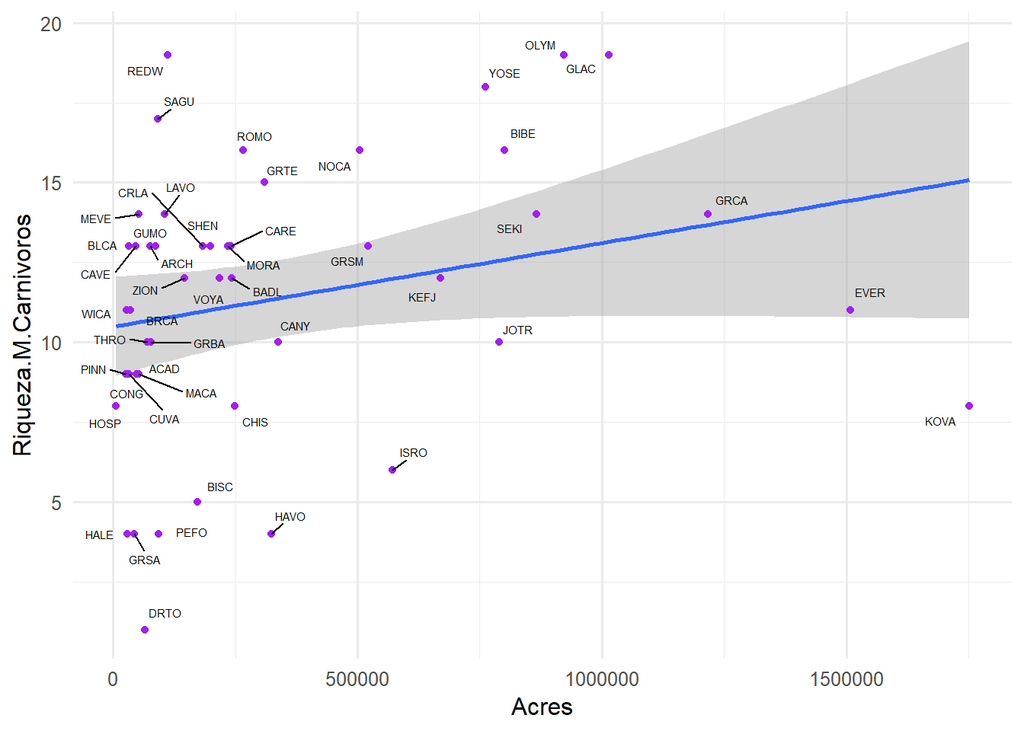

En el gráfico se observa que no existe una relación directa entre la riqueza de mamiferos carnivoros con el área de parque. A continuación se evaluará si esto se cumple también par las especies vegetales presentes.

Gráfico 2: Relación de la riqueza vegetal con el área de los parques. Se muestra para cada punto el código del parque correspondiente (Park.Code en Tabla 1). Ademas se muestra la tendencia de los datos (línea azul) y el intervalo de confianza del 95% (área ploma).

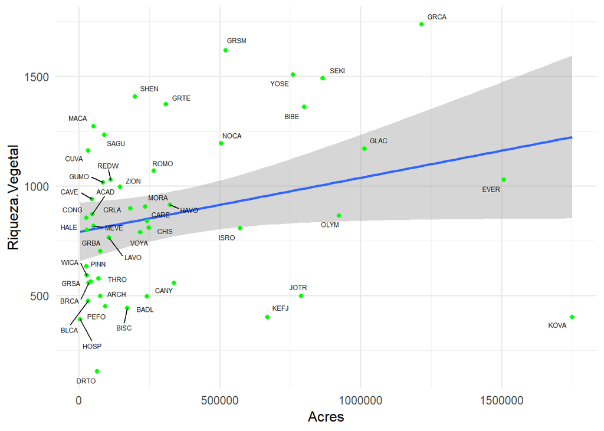

Se observa en el gráfico que no existe relación entre el área y la riqueza vegetal en los parques estado unidenses. Finalmente se hará una exploración para evaluar, considerando la conexión entre niveles tróficos, una posible relación entre la riqueza de mamiferos carnivoros y la riqueza vegetal.

Gráfico 3: Comparación entre la riqueza vegetal y riqueza de mamiferos carnivoros. Se muestra para cada punto el código del parque correspondiente (Park.Code en Tabla 1). Ademas se muestra la tendencia de los datos (línea azul) y el intervalo de confianza del 95% (área ploma). El tamaño de los puntos representa el área del parque.

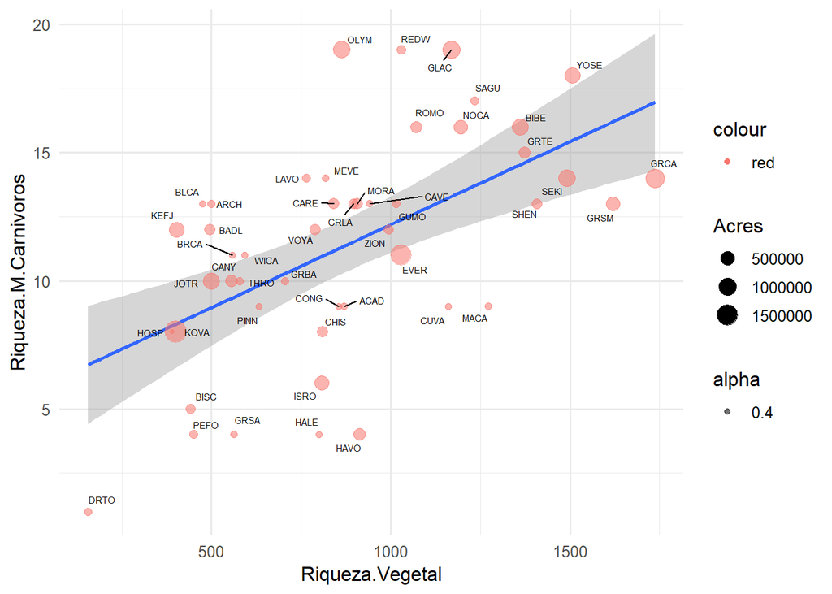

En el Gráfico 3 se observa que pareciera existir una relación directa entre la riqueza vegetal y la riqueza de mamiferos carnivoros, esto tiene sentido biológico dadas las conexiones entre los niveles tróficos qu conectan a productores primarios y consumidores terciarios.